# Week 3 - Homework - STAT 420, Summer 2021

Alejandro Pimentel (ap41)

## Exercise 1 (Using `lm` for Inference)

For this exercise we will use the `cats` dataset from the `MASS` package. You should use `?cats` to learn about the background of this dataset.

**(a)** Fit the following simple linear regression model in `R`. Use heart weight as the response and body weight as the predictor.

$$Y_i = \beta_0 + \beta_1 x_i + \epsilon_i$$

Store the results in a variable called `cat_model`. Use a $t$ test to test the significance of the regression. Report the following:

- The null and alternative hypotheses
- The value of the test statistic
- The p-value of the test
- A statistical decision at $\alpha = 0.05$
- A conclusion in the context of the problem

When reporting these, you should explicitly state them in your document, not assume that a reader will find and interpret them from a large block of `R` output.

```r
fr <- function(nums, digits = 5) {
  format(round(nums, digits), nsmall = digits)
}
```

**Solution**

```r
cats <- MASS::cats
cat_model <- lm(Hwt ~ Bwt, data = cats)
```

Since we are trying to check for a linear relationship between the predictor `(Bwt)` and the response `(Hwt)`, the null and alternative hypothesis for $\beta_1$ is:

$H_0: \beta_1 = 0$ vs $H_1: \beta_1 \neq 0$

The following table shows some of the coefficients for the model:

```r
library(knitr)
library(kableExtra)

coef_cat <- summary(cat_model)$coefficients

get_coef_data <- function(coef) {
  data.frame(
    row.names = c("Beta_0_hat", "Beta_1_hat"),
    "Estimate" = c(coef[1, 1],
                    coef[2, 1]),
    "t value" = c(coef[1, 3],
                    coef[2, 3]),
    "p value" = c(formatC(coef[1, 4],format="e"),
                    formatC(coef[2, 4],format="e"))
  )
}

gen_kable <- function(table_data, row_names = TRUE, caption = "") {
  kable(table_data, format = "html", row.names = row_names,
        caption = caption) %>%
    kable_styling(bootstrap_options = c("striped", "hover"),
                  full_width = F,
                  font_size = 14,
                  position = "center")
}
tdata <- get_coef_data(coef_cat)
gen_kable(tdata, caption = "Coefficients for Linear Model on MASS::cats dataset.")
```

Coefficients for Linear Model on MASS::cats dataset.

|  | Estimate | t.value | p.value |
| --- | --- | --- | --- |
| Beta_0_hat | -0.3566624 | -0.5152019 | 6.0721e-01 |
| Beta_1_hat | 4.0340627 | 16.1193908 | 6.9690e-34 |

```r
stat_decide <- function(p_value, alpha = 0.01) {
  ifelse(p_value < alpha, "Reject the Null Hypothesis", "FTR the Null Hypothesis")
}
(beta_10_decision <- stat_decide(coef_cat[2, 4], alpha = 0.05))
```

```
## [1] "Reject the Null Hypothesis"
```

*Statistical decision at* $\alpha = 0.05$ : **Reject the Null Hypothesis**

Given that we reject the null hypothesis $H_0: \beta_1 = 0$, we can conclude that seems to be a considerable linear relationship between the predictor `(Bwt)` and the response `(Hwt)`. In other words, is reasonable to think that the `Body Weight` can explain some of the variation observed in the `Heart Weight`.

**(b)** Calculate a 95% confidence interval for $\beta_1$. Give an interpretation of the interval in the context of the problem.

**Solution**

```r
(beta_1_interval <- confint(cat_model, parm = "Bwt", level = 0.95))
```

```
##        2.5 %   97.5 %
## Bwt 3.539343 4.528782
```

With `95%` of confidence we can state: The **true value for change in mean** of the `Heart Weight` that corresponds to an increment of `1 kg` of the `Body Weight` is located in the interval: $\left(3.539343, 4.528782\right)$

On this basis we can also reject $H_0: \beta_1 = 0$, since 0 is not in the interval.

**(c)** Calculate a 90% confidence interval for $\beta_0$. Give an interpretation of the interval in the context of the problem.

**Solution**

```r
(beta_0_interval <- confint(cat_model, parm = "(Intercept)", level = 0.9))
```

```
##                   5 %      95 %
## (Intercept) -1.502834 0.7895096
```

With `90%` of confidence we say that, for a `Body Weight` of `0 Kg` the mean of the `Heart Weight` is located in the interval: $\left(-1.502834, 0.7895096\right)$. Note that in reality, negative values of `Heart Weight` do not make sense. Even more, `0 grams` is the only response that seems sensical, but a model would not necessarily reflect that.

**(d)** Use a 90% confidence interval to estimate the mean heart weight for body weights of 2.1 and 2.8 kilograms. Which of the two intervals is wider? Why?

**Solution**

```r
(conf_interval <- predict(cat_model, newdata = data.frame(Bwt = c(2.1, 2.8)),
        interval = c("confidence"), level = 0.9))
```

```
##         fit       lwr       upr
## 1  8.114869  7.787882  8.441856
## 2 10.938713 10.735843 11.141583
```

```r
mean_cats <- c(mean(cats$Bwt), mean(cats$Hwt))
len_interval_21 <- conf_interval[1, 3] - conf_interval[1, 2]
len_interval_28 <- conf_interval[2, 3] - conf_interval[2, 2]
```

*Length of the interval for Btw = 2.1:* 0.653974

*Length of the interval for Btw = 2.8:* 0.4057402

*$\bar{x}$* : 2.7236111

The **interval for `2.1 Kg` is wider** in this case because `2.1` is farther from $\bar{x}$ (`Bwt`). We are less confident in areas with fewer data points (i.e. away from the mean), to account for that, the interval has to be wider.

**(e)** Use a 90% prediction interval to predict the heart weight for body weights of 2.8 and 4.2 kilograms.

**Solution**

```r
(pred_interval <- predict(cat_model, newdata = data.frame(Bwt = c(2.8, 4.2)),
        interval = c("prediction"), level = 0.9))
```

```
##        fit       lwr      upr
## 1 10.93871  8.525541 13.35189
## 2 16.58640 14.097100 19.07570
```

```r
pred_table <- data.frame(
  row.names = c("Beta_0_hat", "Beta_1_hat"),
  "Body Weight" = c(2.8,
                  4.2),
  "Predicted Hwt" = c(pred_interval[1, 1],
                  pred_interval[2, 1]),
  "Lower Bound" = c(pred_interval[1, 2],
                  pred_interval[2, 2]),
  "Upper Bound" = c(pred_interval[1, 3],
                  pred_interval[2, 3])
)


gen_kable(pred_table, caption = "90% Prediction Intervals")
```

90% Prediction Intervals

|  | Body.Weight | Predicted.Hwt | Lower.Bound | Upper.Bound |
| --- | --- | --- | --- | --- |
| Beta_0_hat | 2.8 | 10.93871 | 8.525541 | 13.35189 |
| Beta_1_hat | 4.2 | 16.58640 | 14.097100 | 19.07570 |

**(f)** Create a scatterplot of the data. Add the regression line, 95% confidence bands, and 95% prediction bands.

**Solution**

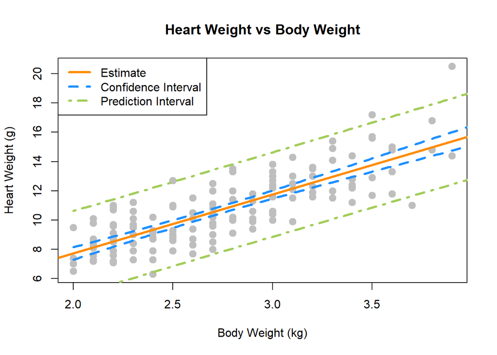

```r
bwt_seq <- seq(min(cats$Bwt), min(cats$Hwt), 0.02)

conf_interval_seq <- predict(cat_model, newdata = data.frame(Bwt = bwt_seq),
        interval = c("confidence"), level = 0.95)

pred_interval_seq <- predict(cat_model, newdata = data.frame(Bwt = bwt_seq),
        interval = c("prediction"), level = 0.95)

#dev.new(width=400, height=300, unit="pixels")

plot(Hwt ~ Bwt, data = cats,
     xlab = "Body Weight (kg)",
     ylab = "Heart Weight (g)",
     main = "Heart Weight vs Body Weight",
     pch = 20,
     cex = 2,
     col = "grey"
     #ylim = c(min(pred_interval_seq), max(pred_interval_seq))
)
abline(cat_model, lwd = 3, col = "darkorange")

lines(bwt_seq, conf_interval_seq[, "lwr"], col = "dodgerblue", lwd = 3, lty = 2)
lines(bwt_seq, conf_interval_seq[, "upr"], col = "dodgerblue", lwd = 3, lty = 2)

lines(bwt_seq, pred_interval_seq[, "lwr"], col = "darkolivegreen3", lwd = 3, lty = 4)
lines(bwt_seq, pred_interval_seq[, "upr"], col = "darkolivegreen3", lwd = 3, lty = 4)

legend("topleft", c("Estimate", "Confidence Interval", "Prediction Interval"),
       lty = c(1, 2, 4),
       lwd = 3,
       col = c("darkorange", "dodgerblue", "darkolivegreen3"))
```

**(g)** Use a $t$ test to test:

- $H_0: \beta_1 = 4$
- $H_1: \beta_1 \neq 4$

Report the following:

- The value of the test statistic
- The p-value of the test
- A statistical decision at $\alpha = 0.05$

When reporting these, you should explicitly state them in your document, not assume that a reader will find and interpret them from a large block of `R` output.

**Solution**

```r
# Since beta_1 for the Null Hyp is not 0, I calculated t and p values using the formulas directly.
beta_1_hat <- cat_model$coefficients[2]
Sxx <- sum((cats$Bwt - mean(cats$Bwt)) ^ 2)
s_e <- summary(cat_model)$sigma
beta_1_hat_t <- (beta_1_hat - 4) / (s_e / sqrt(Sxx))

p_value <- 2 * pt(abs(beta_1_hat_t), df = nrow(cats) - 2, lower.tail = FALSE)

data_Q1g <- data.frame(
  row.names = c("Beta_1_hat"),
  "Estimate" = beta_1_hat,
  "t value" = beta_1_hat_t,
  "p value" = p_value
)

gen_kable(data_Q1g, caption = "Coefficients for beta_1_hat")
```

Coefficients for beta_1_hat

|  | Estimate | t.value | p.value |
| --- | --- | --- | --- |
| Beta_1_hat | 4.034063 | 0.1361084 | 0.8919283 |

```r
(beta_14_decision <- stat_decide(p_value, alpha = 0.05))
```

```
##                       Bwt
## "FTR the Null Hypothesis"
```

*Statistical decision at* $\alpha = 0.05$ : **FTR the Null Hypothesis**

In this case we FTR $H_0: \beta_1 = 4$, since the `p value` is big, in fact, not very far from 1. Also, given that our estimate $\hat\beta_1$ is close to `4` we expected the $H_0$ not to be rejected.

## Exercise 2 (More `lm` for Inference)

For this exercise we will use the `Ozone` dataset from the `mlbench` package. You should use `?Ozone` to learn about the background of this dataset. You may need to install the `mlbench` package. If you do so, do not include code to install the package in your `R` Markdown document.

For simplicity, we will re-perform the data cleaning done in the previous homework.

```r
data(Ozone, package = "mlbench")
Ozone = Ozone[, c(4, 6, 7, 8)]
colnames(Ozone) = c("ozone", "wind", "humidity", "temp")
Ozone = Ozone[complete.cases(Ozone), ]
```

**(a)** Fit the following simple linear regression model in `R`. Use the ozone measurement as the response and wind speed as the predictor.

$$Y_i = \beta_0 + \beta_1 x_i + \epsilon_i$$

Store the results in a variable called `ozone_wind_model`. Use a $t$ test to test the significance of the regression. Report the following:

- The null and alternative hypotheses
- The value of the test statistic
- The p-value of the test
- A statistical decision at $\alpha = 0.01$
- A conclusion in the context of the problem

When reporting these, you should explicitly state them in your document, not assume that a reader will find and interpret them from a large block of `R` output.

**Solution**

Since we are trying to check for a linear relationship between the predictor `(wind)` and the response `(ozone)`, the null and alternative hypothesis for $\beta_1$ is:

$H_0: \beta_1 = 0$ vs $H_1: \beta_1 \neq 0$

```r
ozone_wind_model <- lm(ozone ~ wind, data = Ozone)
ozone_wind_coef <- coef(summary(ozone_wind_model))

tdata <- get_coef_data(ozone_wind_coef)
gen_kable(tdata, caption = "Coefficients for Model on ozone ~ wind.")
```

Coefficients for Model on ozone ~ wind.

|  | Estimate | t.value | p.value |
| --- | --- | --- | --- |
| Beta_0_hat | 11.8635890 | 10.9278455 | 4.8185e-24 |
| Beta_1_hat | -0.0445019 | -0.2189811 | 8.2680e-01 |

```r
(beta_10_decision <- stat_decide(ozone_wind_coef[2, 4], alpha = 0.01))
```

```
## [1] "FTR the Null Hypothesis"
```

*Statistical decision at* $\alpha = 0.01$ : **FTR the Null Hypothesis**

Given that we FTR the null hypothesis $H_0: \beta_1 = 0$, we can conclude that doesn’t seem to be a clear linear relationship between the predictor `(wind)` and the response `(ozone)`. In other words, the `Wind Speed` **cannot** explain the variation observed in the `Ozone` levels.

**(b)** Fit the following simple linear regression model in `R`. Use the ozone measurement as the response and temperature as the predictor.

$$Y_i = \beta_0 + \beta_1 x_i + \epsilon_i$$

Store the results in a variable called `ozone_temp_model`. Use a $t$ test to test the significance of the regression. Report the following:

- The null and alternative hypotheses
- The value of the test statistic
- The p-value of the test
- A statistical decision at $\alpha = 0.01$
- A conclusion in the context of the problem

When reporting these, you should explicitly state them in your document, not assume that a reader will find and interpret them from a large block of `R` output.

**Solution**

Since we are trying to check for a linear relationship between the predictor `(temp)` and the response `(ozone)`, the null and alternative hypothesis for $\beta_1$ is:

$H_0: \beta_1 = 0$ vs $H_1: \beta_1 \neq 0$

```r
ozone_temp_model <- lm(ozone ~ temp, data = Ozone)
ozone_temp_coef <- coef(summary(ozone_temp_model))

tdata <- get_coef_data(ozone_temp_coef)
gen_kable(tdata, caption = "Coefficients for Model on ozone ~ temp")
```

Coefficients for Model on ozone ~ temp

|  | Estimate | t.value | p.value |
| --- | --- | --- | --- |
| Beta_0_hat | -14.8847975 | -12.48425 | 9.9475e-30 |
| Beta_1_hat | 0.4296785 | 22.84896 | 8.1538e-71 |

```r
(beta_10_decision <- stat_decide(ozone_temp_coef[2, 4], alpha = 0.01))
```

```
## [1] "Reject the Null Hypothesis"
```

*Statistical decision at* $\alpha = 0.01$ : **Reject the Null Hypothesis**

Given that we reject the null hypothesis $H_0: \beta_1 = 0$, we can conclude that seems to be a considerable linear relationship between the predictor `(temp)` and the response `(ozone)`. In other words, is reasonable to think that the `temp` can explain some of the variation observed in the `ozone`.

## Exercise 3 (Simulating Sampling Distributions)

For this exercise we will simulate data from the following model:

$$Y_i = \beta_0 + \beta_1 x_i + \epsilon_i$$

Where $\epsilon_i \sim N(0, \sigma^2).$ Also, the parameters are known to be:

- $\beta_0 = -5$
- $\beta_1 = 3.25$
- $\sigma^2 = 16$

We will use samples of size $n = 50$.

**(a)** Simulate this model $2000$ times. Each time use `lm()` to fit a simple linear regression model, then store the value of $\hat{\beta}_0$ and $\hat{\beta}_1$. Set a seed using **your** birthday before performing the simulation. Note, we are simulating the $x$ values once, and then they remain fixed for the remainder of the exercise.

```r
birthday = 19820426
set.seed(birthday)
n = 50
x = seq(0, 10, length = n)
```

**Solution**

```r
sim_slr <- function(x, beta_0, beta_1, sigma = 1) {
  n <- length(x)
  epsilon <- rnorm(n = n, mean = 0, sd = sigma)
  y <- beta_0 + beta_1 * x + epsilon
  data.frame(predictor = x, response = y)
}

loop_simulation <- function (x_vals, beta_0, beta_1, num_simulations = 1500, sigma = 1) {
  beta_1_hats <- rep(0, num_simulations)
  beta_0_hats <- rep(0, num_simulations)
  # Standard Errors for each beta_1_hat
  beta_1_hats_se <- rep(0, num_simulations)
  for (i in 1:num_simulations) {
    sim_data <- sim_slr(x = x_vals, beta_0 = beta_0, beta_1 = beta_1, sigma = sigma)
    sim_model <- lm(response ~ predictor, data = sim_data)
    beta_0_hats[i] <- sim_model$coefficients[1]
    beta_1_hats[i] <- sim_model$coefficients[2]
    beta_1_hats_se[i] <- summary(sim_model)$coefficients[2, 2]
  }
  list(
    beta_0_hats = beta_0_hats,
    beta_1_hats = beta_1_hats,
    beta_1_hats_se = beta_1_hats_se
    )
}

beta_hats <- loop_simulation(x, -5, 3.25, num_simulations = 2000, sigma = 4)
```

**(b)** Create a table that summarizes the results of the simulations. The table should have two columns, one for $\hat{\beta}_0$ and one for $\hat{\beta}_1$. The table should have four rows:

- A row for the true expected value given the known values of $x$
- A row for the mean of the simulated values
- A row for the true standard deviation given the known values of $x$
- A row for the standard deviation of the simulated values

**Solution**

```r
# model parameters
beta_0 <- -5
beta_1 <- 3.25
sigma <- 4

# true values
Sxx <- sum((x - mean(x)) ^ 2)
var_beta_1_hat <- sigma ^ 2 / Sxx
var_beta_0_hat <- sigma ^ 2 * (1/n + mean(x) ^ 2 / Sxx)

data_Q3b <- data.frame(
  row.names = c("Expected (true mean)", "Mean from simulation", "Expected SD", "SD from simulation"),
  "beta_0_hat" = c(fr(beta_0, 2), fr(mean(beta_hats$beta_0_hats)),
                   fr(sqrt(var_beta_0_hat)), fr(sd(beta_hats$beta_0_hats))),
  "beta_1_hat" = c(fr(beta_1, 2), fr(mean(beta_hats$beta_1_hats)),
                   fr(sqrt(var_beta_1_hat)), fr(sd(beta_hats$beta_1_hats)))
)

gen_kable(data_Q3b, caption = "True values vs Simulation values")
```

True values vs Simulation values

|  | beta_0_hat | beta_1_hat |
| --- | --- | --- |
| Expected (true mean) | -5.00 | 3.25 |
| Mean from simulation | -5.00549 | 3.25370 |
| Expected SD | 1.11461 | 0.19208 |
| SD from simulation | 1.15614 | 0.19825 |

**(c)** Plot two histograms side-by-side:

- A histogram of your simulated values for $\hat{\beta}_0$. Add the normal curve for the true sampling distribution of $\hat{\beta}_0$.
- A histogram of your simulated values for $\hat{\beta}_1$. Add the normal curve for the true sampling distribution of $\hat{\beta}_1$.

**Solution**

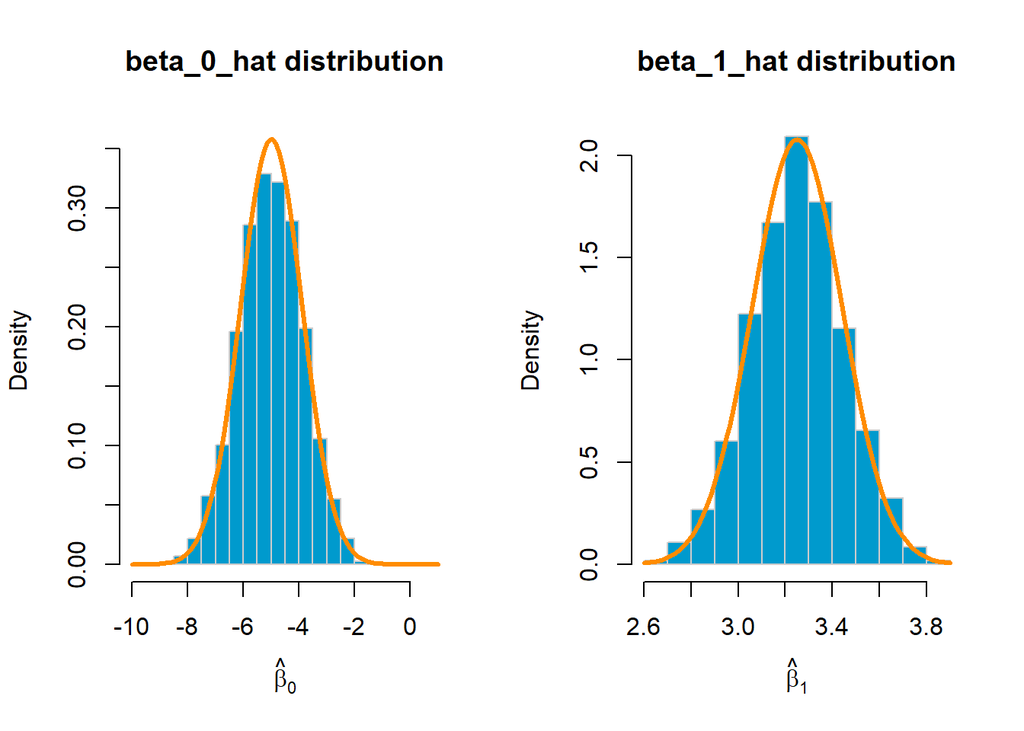

```r
par(mfrow=c(1, 2))
hist(beta_hats$beta_0_hats,
     xlab   = expression(hat(beta)[0]),
     main   = "beta_0_hat distribution",
     col  = "deepskyblue3",
     border = "gray80",
     breaks = 15,
     prob = TRUE,
     ylim = c(0, 0.36),
     xlim = c(-10, 1)
     )
curve(dnorm(x, mean = beta_0, sd = sqrt(var_beta_0_hat)),
      col = "darkorange", add = TRUE, lwd = 3)

hist(beta_hats$beta_1_hats,
     xlab   = expression(hat(beta)[1]),
     main   = "beta_1_hat distribution",
     col  = "deepskyblue3",
     border = "gray80",
     prob = TRUE
     )
curve(dnorm(x, mean = beta_1, sd = sqrt(var_beta_1_hat)),
      col = "darkorange", add = TRUE, lwd = 3)
```

## Exercise 4 (Simulating Confidence Intervals)

For this exercise we will simulate data from the following model:

$$Y_i = \beta_0 + \beta_1 x_i + \epsilon_i$$

Where $\epsilon_i \sim N(0, \sigma^2).$ Also, the parameters are known to be:

- $\beta_0 = 5$
- $\beta_1 = 2$
- $\sigma^2 = 9$

We will use samples of size $n = 25$.

Our goal here is to use simulation to verify that the confidence intervals really do have their stated confidence level. Do **not** use the `confint()` function for this entire exercise.

**(a)** Simulate this model $2500$ times. Each time use `lm()` to fit a simple linear regression model, then store the value of $\hat{\beta}_1$ and $s_e$. Set a seed using **your** birthday before performing the simulation. Note, we are simulating the $x$ values once, and then they remain fixed for the remainder of the exercise.

```r
birthday = 19820426
set.seed(birthday)
n = 25
x = seq(0, 2.5, length = n)
```

**Solution**

```r
# model parameters
beta_0 <- 5
beta_1 <- 2
sigma <- 3

sim_stats <- loop_simulation(x, beta_0, beta_1, num_simulations = 2500, sigma = sigma)
```

**(b)** For each of the $\hat{\beta}_1$ that you simulated, calculate a 95% confidence interval. Store the lower limits in a vector `lower_95` and the upper limits in a vector `upper_95`. Some hints:

- You will need to use `qt()` to calculate the critical value, which will be the same for each interval.
- Remember that `x` is fixed, so $S_{xx}$ will be the same for each interval.
- You could, but do not need to write a `for` loop. Remember vectorized operations.

**Solution**

```r
crit <- qt(0.025, df = n - 2, lower.tail = FALSE)
margin <- crit * sim_stats$beta_1_hats_se
lower_95 <- sim_stats$beta_1_hats - margin
upper_95 <- sim_stats$beta_1_hats + margin

# Let's take a look to some
lower_95[1:10]
```

```
##  [1] -0.9496968  0.5865253  0.4059017  0.5517540  0.5248745  1.3087856
##  [7]  0.5389373  1.8275487  1.4187764  0.6082860
```

```r
upper_95[1:10]
```

```
##  [1] 2.281783 3.541736 4.179022 3.533827 4.080422 4.249322 3.231714 5.196986
##  [9] 5.251385 5.011852
```

**(c)** What proportion of these intervals contains the true value of $\beta_1$?

**Solution**

```r
len <- length(lower_95)
beta_1_in_count <- sum(beta_1 > lower_95 & beta_1 < upper_95)
(proportion <- beta_1_in_count / len)
```

```
## [1] 0.946
```

**2365** of the confident intervals include $\beta_1 = 2$, that is a proportion of **0.946**

**(d)** Based on these intervals, what proportion of the simulations would reject the test $H_0: \beta_1 = 0$ vs $H_1: \beta_1 \neq 0$ at $\alpha = 0.05$?

**Solution**

```r
beta_10_out_count <- len - sum(0 > lower_95 & 0 < upper_95)
(proportion_0 <- beta_10_out_count / len)
```

```
## [1] 0.6536
```

$\beta_1 = 0$ **is not** included in **1634** of the **2500** intervals. That is proportion of **0.6536** that reject the test $H_0: \beta_1 = 0$ vs $H_1: \beta_1 \neq 0$

**(e)** For each of the $\hat{\beta}_1$ that you simulated, calculate a 99% confidence interval. Store the lower limits in a vector `lower_99` and the upper limits in a vector `upper_99`.

**Solution**

```r
crit <- qt(0.005, df = n - 2, lower.tail = FALSE)
margin <- crit * sim_stats$beta_1_hats_se
lower_99 <- sim_stats$beta_1_hats - margin
upper_99 <- sim_stats$beta_1_hats + margin

# Let's take a look to some
lower_99[1:10]
```

```
##  [1] -1.52664649  0.05890065 -0.26775280  0.01933339 -0.10993457  0.78378105
##  [7]  0.05816785  1.22596791  0.73450081 -0.17792867
```

```r
upper_99[1:10]
```

```
##  [1] 2.858732 4.069361 4.852676 4.066248 4.715231 4.774326 3.712483 5.798567
##  [9] 5.935660 5.798067
```

**(f)** What proportion of these intervals contains the true value of $\beta_1$?

**Solution**

```r
len <- length(lower_99)
beta_1_in_count <- sum(beta_1 > lower_99 & beta_1 < upper_99)
(proportion <- beta_1_in_count / len)
```

```
## [1] 0.9884
```

**2471** of the confident intervals include $\beta_1 = 2$, that is a proportion of **0.9884**

**(g)** Based on these intervals, what proportion of the simulations would reject the test $H_0: \beta_1 = 0$ vs $H_1: \beta_1 \neq 0$ at $\alpha = 0.01$?

**Solution**

```r
beta_10_out_count <- len - sum(0 > lower_99 & 0 < upper_99)
(proportion_0 <- beta_10_out_count / len)
```

```
## [1] 0.386
```

$\beta_1 = 0$ **is not** included in **965** of the **2500** intervals. That is proportion of **0.386** that reject the test $H_0: \beta_1 = 0$ vs $H_1: \beta_1 \neq 0$

## Exercise 5 (Prediction Intervals “without” `predict`)

Write a function named `calc_pred_int` that performs calculates prediction intervals:

$$\hat{y}(x) \pm t_{\alpha/2, n - 2} \cdot s_e\sqrt{1 + \frac{1}{n}+\frac{(x-\bar{x})^2}{S_{xx}}}.$$

for the linear model

$$Y_i = \beta_0 + \beta_1 x_i + \epsilon_i.$$

**(a)** Write this function. You may use the `predict()` function, but you may **not** supply a value for the `level` argument of `predict()`. (You can certainly use `predict()` any way you would like in order to check your work.)

The function should take three inputs:

- `model`, a model object that is the result of fitting the SLR model with `lm()`
- `newdata`, a data frame with a single observation (row)
  - This data frame will need to have a variable (column) with the same name as the data used to fit `model`.
- `level`, the level (0.90, 0.95, etc) for the interval with a default value of `0.95`

The function should return a named vector with three elements:

- `estimate`, the midpoint of the interval
- `lower`, the lower bound of the interval
- `upper`, the upper bound of the interval

**Solution**

```r
calc_pred_int <- function(model, newdata, level = 0.95) {
  estimate <- predict(model, newdata = newdata)
  n <- length(model$fitted.values)
  crit <- qt((1 - level) / 2, df = model$df.residual, lower.tail = FALSE)

  x_mean <- mean(model$model[, names(newdata)])
  Sxx <- sum((model$model[, names(newdata)] - x_mean) ^ 2)

  s_e <- summary(model)$sigma
  s_err <- s_e * sqrt(1 + 1/n + ((newdata[, 1] - x_mean)^2) / Sxx)

  margin <- crit * s_err
  lower <- estimate - margin
  upper <- estimate + margin

  pred_int <- c(estimate, lower, upper)
  names(pred_int) <- c("estimate", "lower", "upper")

  pred_int
}
```

**(b)** After writing the function, run this code:

```r
newcat_1 = data.frame(Bwt = 4.0)
calc_pred_int(cat_model, newcat_1)
```

```
## estimate    lower    upper
## 15.77959 12.83018 18.72900
```

**(c)** After writing the function, run this code:

```r
newcat_2 = data.frame(Bwt = 3.3)
calc_pred_int(cat_model, newcat_2, level = 0.90)
```

```
## estimate    lower    upper
## 12.95574 10.53099 15.38050
```